# River Flow for Nature vs Irrigation

An environmental-flow rule in five TaqSim blocks, scored with fishy

Author

Affiliation

Dr. Tobias Siegfried

[hydrosolutions GmbH](https://www.hydrosolutions.ch)

Published

October 8, 2026

[figure not shown]

**hydrosolutions GmbH** · Venusstrasse 29, 8050 Zürich, Switzerland · www.hydrosolutions.ch · hs@hydrosolutions.ch · +41 43 535 05 80

# 1 The question

A river feeds a canal. The canal feeds the fields of Samarkand. Everything the canal does not take stays in the river and flows on. The question for the operator of the headworks is not only *how much* water to leave in the river, but *how* to leave it:

- **Leave a share.** Each day, a fixed share of the day’s flow stays in the river, whatever the flow is.
- **Guarantee a minimum.** Each day, the first so-many cubic metres per second stay in the river; the canal takes only from what is above that.

Both can give the crops the same water over a year. They do not give the river the same regime. This notebook builds the smallest TaqSim model that shows the difference, on the real Zarafshan at Ravatkhoja, and scores the river with an index of hydrological alteration.

**What you will take away**

1. How TaqSim’s environmental-flow rule (`EFlowSplit`) works, and how to wire it between a source, a canal and a sink.
2. How an alteration index (fishy’s IARI, built on the 33 IHA indicators) turns a daily flow series into one number, and what that number leaves out.
3. Why, for the same water to the crops, a guaranteed minimum flow gives a river closer to natural than a share does: the shape of a rule matters, not only its volume.

> **The technical words.** The water left in the river for nature is the *environmental flow* (e-flow). The 33 *Indicators of Hydrologic Alteration* (IHA; Richter et al. 1996) describe a flow regime by its magnitudes, timing, extremes, pulses and rates of change. The *IARI* (ISPRA 2011) compares those indicators between a natural and an altered series and averages the result: 0 means inside the natural range on every indicator. A plan that no other plan beats on both goals is *Pareto-optimal*; this notebook says “unbeaten”.

# 2 The system in five blocks

TaqSim describes a water system as a network of blocks joined by edges. Ours has five blocks and five edges: an inflow, two reaches that carry the rules, and two sinks.

```python
# Standard tools
import inspect  # to show the source of a function inside this notebook
import json
import logging
from pathlib import Path

import matplotlib.pyplot as plt
import numpy as np
import polars as pl  # tables; the new TaqSim and fishy both speak polars
from IPython.display import Markdown

# The game's reference model (workshop/eflow_game/src/eflow_game/model.py): the TaqSim system, the fishy scoring,
# the plan grid and the export. Everything the game page shows was computed by these functions.
from eflow_game import model as m
from eflow_game.model import Plan, build_system, demand_curve, load_inflow, run_year, score_river, twin_year

logging.basicConfig(level=logging.WARNING)
DAY = 86400.0

# The precomputed grid: every plan, run in TaqSim for 2019-2023 and scored with fishy
DATA = json.loads(m.DATA_FILE.read_text())
PLANS = pl.DataFrame(DATA["plans"]).select(
    "id", "name", "share_pct", "ceiling_m3s", "crops_pct", "score", "score_is_total", "scored", "classification", "unbeaten", "lowest_flow_m3s"
)
META = DATA["meta"]
Markdown(
    f"Loaded {len(DATA['plans'])} plans ({META['runs']} TaqSim runs of one year, {META['mean_run_seconds']:.1f} s each on "
    f"{META['workers']} processes, {META['wall_seconds_total'] / 60:.1f} min in all; built {META['built']})."
)
```

Loaded 91 plans (455 TaqSim runs of one year, 12.3 s each on 10 processes, 9.4 min in all; built 2026-10-06T13:20:55).

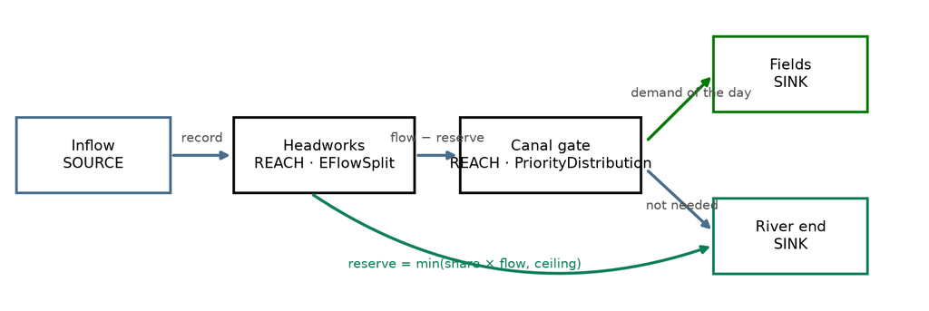

Figure 1: The model as a network. Water flows from left to right. The two reaches carry the rules; the sinks only record what arrives.

| Block | Kind | Rule | On the real river |
| --- | --- | --- | --- |
| Inflow | Source | passes on the recorded daily flow | the Zarafshan at the Ravatkhoja gauge |
| Headworks | Reach with `EFlowSplit` | reserves min(share × flow, ceiling) for the river, passes the rest on | the Ravatkhoja headworks |
| Canal gate | Reach with `PriorityDistribution` | gives the fields the day’s demand, returns the rest to the river | the head of the Samarkand canals |
| Fields | Sink | records what arrives: the crops’ water | Dargom, Mirzapay, Akkaradarya |
| River end | Sink | records what arrives: the river for nature | the Zarafshan below Ravatkhoja |

Nothing is stored and nothing is lost between the blocks, so on every day *inflow = river end + fields*. The model runs day by day, one calendar year per run, and the five years 2019–2023 are scored together.

## 2.1 The river

```python
# The daily record at Ravatkhoja, 2010-2023, as the model reads it: columns date and q (m³/s)
inflow = load_inflow()
by_year = inflow.group_by(inflow["date"].dt.year().alias("year")).agg(pl.col("q").mean().round(1).alias("mean_m3s"), pl.col("q").min().alias("min_m3s"), pl.col("q").max().alias("max_m3s")).sort("year")
by_year
```

shape: (14, 4)

| year i32 | mean_m3s f64 | min_m3s f64 | max_m3s f64 |
| --- | --- | --- | --- |
| 2010 | 154.2 | 38.5 | 508.0 |
| 2011 | 130.9 | 39.7 | 391.0 |
| 2012 | 153.4 | 40.4 | 538.0 |
| 2013 | 144.7 | 44.3 | 483.0 |
| 2014 | 115.2 | 38.5 | 411.0 |
| … | … | … | … |
| 2019 | 156.4 | 33.7 | 680.0 |
| 2020 | 118.1 | 36.0 | 319.0 |
| 2021 | 94.1 | 25.8 | 281.0 |
| 2022 | 127.2 | 32.3 | 486.0 |
| 2023 | 119.1 | 36.0 | 446.0 |

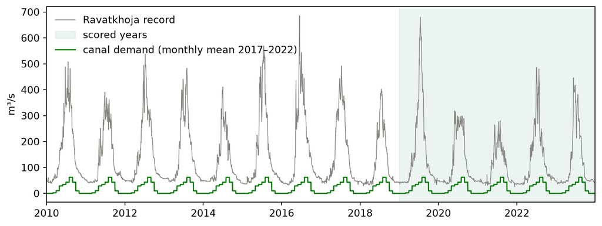

Figure 2: The natural reference (grey, all 14 years) and the canal’s demand curve (green). The five scored years are shaded.

Two facts decide everything that follows. The canal asks for little against the river: a mean of 19.6 m³/s against a mean flow of 135 m³/s, and nothing from November to February. And it asks at the wrong time for the river: the demand starts in March, while the river is still at its winter low, peaks in August and is still 43 m³/s in September, when the summer flood has receded.

# 3 The rule with two levers

TaqSim’s `EFlowSplit` reserves an environmental flow before anything else is allocated. It has two parameters:

- `eflow_fraction`, the **reserve share** of the day’s flow (0 to 1);
- `eflow_cap`, the **reserve ceiling**: the reserve never exceeds this volume per day.

The reserve of the day is *min(share × flow, ceiling)*. A share of 100 % with a ceiling of 60 m³/s therefore means: the first 60 m³/s of every day stay in the river. A share of 50 % with no ceiling means: half of every day’s flow stays. The `PriorityDistribution` rule at the canal gate then serves the fields first, up to the month’s demand, and sends whatever remains back to the river.

```python
# The function that wires the five blocks for one calendar year under one plan. Read it top to bottom:
# a time axis of daily steps, the inflow as an IntervalVolume, two sinks, the two reaches with their rules.
print(inspect.getsource(build_system))
```

```
def build_system(year: int, plan: Plan, inflow: pl.DataFrame | None = None) -> Any:
    """The five-block TaqSim system for one calendar year under one plan (built, not run)."""
    from taqsim import EFlowSplit, IntervalVolume, Parameter, PriorityDistribution, TimeAxis, WaterSystem, WaterVolume

    inflow = load_inflow() if inflow is None else inflow
    year_frame = inflow.filter(pl.col("date").dt.year() == year)
    series = pl.DataFrame(
        {"time": year_frame["date"].cast(pl.Datetime("us")), "value": (year_frame["q"] * DAY).round(0)}
    )
    system = WaterSystem(
        time=TimeAxis(datetime(year, 1, 1), year_frame.height, "1d"), quantum="1 m3", name="eflow-game"
    )
    system.source("inflow", IntervalVolume(series, "m3", "1d", "1 m3"))
    system.sink("fields")
    system.sink("river_end")
    system.reach(
        "headworks",
        "inflow",
        "canal_gate",
        rule=EFlowSplit(
            natural_ratios={"river_end": 1.0},
            remainder_ratios={"canal_gate": 1.0},
            eflow_fraction=Parameter("reserve_share", plan.share_pct / 100, (0.0, 1.0)),
            eflow_cap=WaterVolume(plan.cap_m3s * DAY, "m3"),
        ),
    )
    system.reach(
        "canal_gate",
        "headworks",
        "fields",
        rule=PriorityDistribution(
            "fields", tuple(WaterVolume(round(v * DAY), "m3") for v in demand_curve()), {"river_end": 1.0}
        ),
    )
    return system.build()
```

A few plans in words, as the game names them:

```python
for plan in (Plan(0, None), Plan(50, None), Plan(100, 60.0), Plan(50, 60.0), Plan(100, None)):
    print(f"share {plan.share_pct:3d} %, ceiling {'none' if plan.ceiling_m3s is None else f'{plan.ceiling_m3s:.0f} m³/s':10s} → {plan.name}")
```

```
share   0 %, ceiling none       → Canal takes all it needs
share  50 %, ceiling none       → Leave 50 % of each day's flow
share 100 %, ceiling 60 m³/s    → First 60 m³/s always stay
share  50 %, ceiling 60 m³/s    → Leave 50 %, at most 60 m³/s
share 100 %, ceiling none       → River untouched
```

# 4 Build and run one year

Let us run the driest of the scored years, 2021, under the plan “first 60 m³/s always stay”. The run takes a few seconds: TaqSim’s new engine records every allocation it makes, so that the run can be replayed and audited.

```python
plan = Plan(100, 60.0)
run = run_year(2021, plan)  # a YearRun: dates, natural, river and fields in m³/s, and the run time
demand = m.demand_daily(run.dates)
crops_2021 = 100 * run.fields.sum() / demand.sum()
Markdown(
    f"Run time {run.seconds:.1f} s for {len(run.dates)} daily steps. Mass balance residual {run.mass_balance_residual_m3():.0f} m³. "
    f"Fields received {crops_2021:.1f} % of their demand. Lowest flow below the headworks {run.river.min():.1f} m³/s "
    f"(natural {run.natural.min():.1f})."
)
```

Run time 4.5 s for 365 daily steps. Mass balance residual 0 m³. Fields received 89.8 % of their demand. Lowest flow below the headworks 25.8 m³/s (natural 25.8).

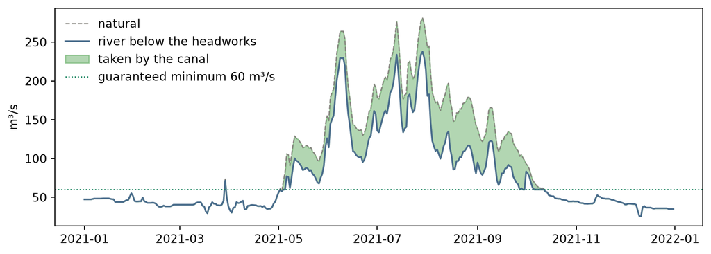

Figure 3: 2021 under “first 60 m³/s always stay”. The green band is the water the canal took.

The same two rules fit in four lines of numpy. The model keeps this twin to check every TaqSim run: the two agree to the engine’s quantum of 1 m³ per day.

```python
print(inspect.getsource(twin_year))
river_twin, fields_twin = twin_year(run.natural, demand, plan)
print("largest difference TaqSim − twin:", f"{np.abs(river_twin - run.river).max() * DAY:.2f} m³/day")
```

```
def twin_year(natural: np.ndarray, demand: np.ndarray, plan: Plan) -> tuple[np.ndarray, np.ndarray]:
    """The same two rules in numpy (river, fields in m³/s); checked against TaqSim in the tests."""
    reserve = np.minimum(plan.share_pct / 100 * natural, plan.cap_m3s)
    fields = np.minimum(demand, natural - reserve)
    return natural - fields, fields

largest difference TaqSim − twin: 0.40 m³/day
```

# 5 Score the river

The river score is fishy’s IARI. It needs the 33 IHA indicators of the natural record, year by year, and the same 33 of the altered series over its last five years. For each indicator it asks: does the five-year value lie inside the natural interquartile range? If yes, the indicator scores 0; if not, the distance outside, relative to the range. The index is the mean of the 33. ISPRA’s bounds: ≤ 0.05 close to natural, ≤ 0.15 good, above that altered.

Two things to say before the numbers. The method asks for at least 20 reference years; the Ravatkhoja record has 14 (2010–2023), and the project lead decided to use the available data, so the model patches fishy’s check (see `model._fishy`). And when fishy cannot score an indicator, it returns no total; the game then shows the mean of the indicators it could score, says how many, and lists why.

```python
# Score two plans over the five years 2019-2023. run_grid runs the years in a process pool (about ten seconds).
# The two example plans of the game page: the share-only and the minimum-only plan that the export paired
examples = [Plan(p["share_pct"], p["ceiling_m3s"]) for p in DATA["plans"] if p["id"] in META["teaching_pair"]]
runs = m.run_grid(examples, workers=5)
results = {p.id: m.evaluate_plan(p, runs[p.id]) for p in examples}
for r in results.values():
    s = r.river
    print(f"{r.plan.name:32s} crops {r.crops_pct:5.1f} %  score {s.score:.3f} ({'all 33' if s.total is not None else f'{s.scored} of 33'} indicators)  class {s.classification}")
    for w in r.warnings:
        print("   ⚠", w)
```

```
Leave 80 % of each day's flow    crops  81.9 %  score 0.167 (32 of 33 indicators)  class None
   ⚠ 1 of 33 indicators could not be scored (minimum_flow_date); the score is the mean of the other 32
   ⚠ minimum flow date: the date of the lowest flow cannot be scored: in the natural record it falls near the turn of the year, so the index cannot place the plan's dates on a circular axis
   ⚠ river below the lowest natural flow on record (25.8 m³/s) on 1 of 1826 days
First 80 m³/s always stay        crops  83.8 %  score 0.151 (all 33 indicators)  class non_buono
```

Nearly the same water for the crops; a different river. Which indicators make the difference?

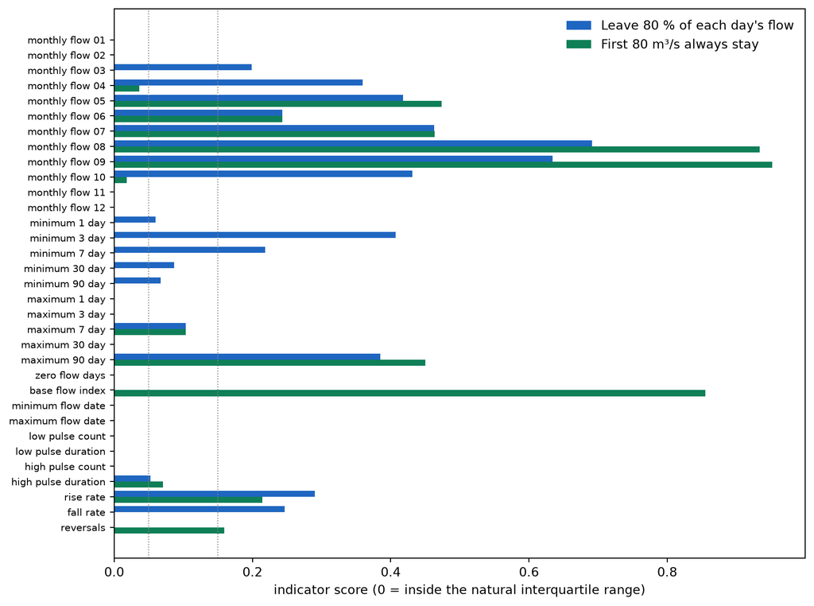

Figure 4: The 33 indicator scores of the two plans. Longer is further from the natural range.

The share takes the most water, in absolute terms, on the days of highest flow, which barely matters to the index: those days stay inside the natural range. But it also takes its share on the lowest days of spring, when the canal has just started: the 1-, 3- and 7-day minima and the mean flows of the spring months move outside the natural range. The guaranteed minimum takes nothing on those days. (Plan A can score only 32 of the 33 indicators, so its score is the mean of 32; on those same 32, plan B’s mean is given below.)

```python
common = [k for k, v in a.river.indicators.items() if v is not None and b.river.indicators[k] is not None]
for r in (a, b):
    print(f"{r.plan.name:32s} mean over the {len(common)} indicators both can score: {np.mean([r.river.indicators[k] for k in common]):.3f}")
```

```
Leave 80 % of each day's flow    mean over the 32 indicators both can score: 0.167
First 80 m³/s always stay        mean over the 32 indicators both can score: 0.155
```

# 6 Every plan at once

The game page carries a grid of every lever combination: shares of 0–100 % in steps of 10, ceilings of 10, 20, 40, 60, 80, 100, 150 and 200 m³/s or none. A share of 0 % is the same plan whatever the ceiling, so it appears once: 91 plans, each run in TaqSim for 2019–2023 and scored with fishy. Loading the precomputed result instead of recomputing it keeps this notebook short.

```python
PLANS.filter(pl.col("unbeaten")).sort("crops_pct", descending=True)
```

shape: (43, 11)

| id str | name str | share_pct i64 | ceiling_m3s f64 | crops_pct f64 | score f64 | score_is_total bool | scored i64 | classification str | unbeaten bool | lowest_flow_m3s f64 |
| --- | --- | --- | --- | --- | --- | --- | --- | --- | --- | --- |
| "s0_cnone" | "Canal takes all it needs" | 0 | null | 100.0 | 0.30059 | false | 32 | null | true | 17.419 |
| "s10_c10" | "Leave 10 %, at most 10 m³/s" | 10 | 10.0 | 100.0 | 0.30059 | false | 32 | null | true | 17.419 |
| "s10_c20" | "Leave 10 %, at most 20 m³/s" | 10 | 20.0 | 100.0 | 0.30059 | false | 32 | null | true | 17.419 |
| "s10_c40" | "Leave 10 %, at most 40 m³/s" | 10 | 40.0 | 100.0 | 0.30059 | false | 32 | null | true | 17.419 |
| "s10_c60" | "Leave 10 %, at most 60 m³/s" | 10 | 60.0 | 100.0 | 0.30059 | false | 32 | null | true | 17.419 |
| … | … | … | … | … | … | … | … | … | … | … |
| "s100_c80" | "First 80 m³/s always stay" | 100 | 80.0 | 83.824 | 0.15067 | true | 33 | "non_buono" | true | 25.8 |
| "s100_c100" | "First 100 m³/s always stay" | 100 | 100.0 | 76.164 | 0.12702 | true | 33 | "buono" | true | 25.8 |
| "s100_c150" | "First 150 m³/s always stay" | 100 | 150.0 | 56.575 | 0.10131 | true | 33 | "buono" | true | 25.8 |
| "s100_c200" | "First 200 m³/s always stay" | 100 | 200.0 | 40.002 | 0.08277 | true | 33 | "buono" | true | 25.8 |
| "s100_cnone" | "River untouched" | 100 | null | 0.0 | 0.00444 | true | 33 | "elevato" | true | 25.8 |

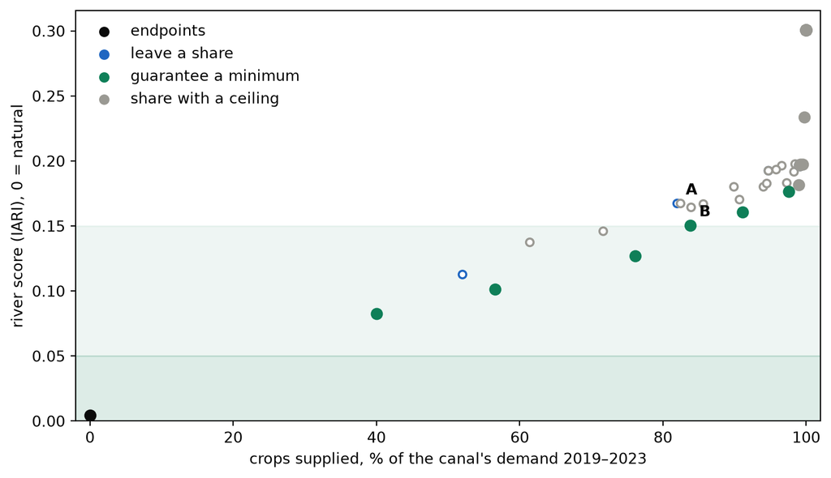

Figure 5: Every plan: crops supplied against the river score. Filled dots are the plans no other plan beats. Right is better for the crops; down is better for the river.

# 7 What to notice

2. **A share does little until it is large.** Of the share-only plans, 5 of 9 change nothing for the crops, because the canal rarely needs more than what is left. The score does not move at all up to 40 % and the river stays “altered” up to 80 %; it is “good” only at 90 %, when the crops get 52.0 %.

3. **The same water, a different river.** Example A, “Leave 80 % of each day’s flow”, gives the crops 81.9 % at a score of 0.167; Example B, “First 80 m³/s always stay”, gives 83.8 % at 0.151. The minimum protects the low-flow days; the share leaves them exposed.

4. **The unbeaten plans.** 43 of 91 plans are beaten by no other plan; 7 of them are guaranteed minima. Choosing among them is a decision about how much river to trade for how much crop, not a calculation.

# 8 Limits

- **One canal.** At Ravatkhoja the real headworks also feed the transfers to Jizzakh and Kashkadarya and further canals; here only the three Samarkand canals divert, so the real canal share is larger and the real trade-off sharper.
- **No storage, losses or return flow.** The canal has no seepage, the fields drain nothing back, and nothing is carried from one day to the next. The game is about the headworks’ rule, not the basin.
- **A fixed demand curve.** The canal asks for the same monthly volumes every year; a dry year does not change what the crops need.
- **The same rule every day.** Real environmental-flow rules vary by season and by type of year, and the literature designs them with many objectives at once (Suen & Eheart 2006; Chen & Olden 2017). Here the two levers are constant all year.
- **The reference is the recent regime.** The Zarafshan at Ravatkhoja is regulated upstream; 2010–2023 is the recent record, not a pristine river. And it has 14 years where the method asks for 20, so the natural quartiles are less certain than the method assumes, and the five scored years overlap the reference.
- **One index.** The IARI measures hydrological alteration; it says nothing about fish, temperature or sediment.

# 9 Exercises

1. Run `Plan(100, 40.0)` for 2021 with `run_year` and check the lowest flow below the headworks. Why is it not 40 m³/s? (Look at the natural minimum in Section 2.1.)
2. Add a third rule family: a share that applies only from March to May. The `EFlowSplit` rule cannot do this by itself; sketch which block you would add, and what its rule would be.
3. Replace the demand curve with the six-canal total of the demand file (`m.SAMARKAND_CANALS` plus the other three columns) and recompute the two example plans. How does the trade-off change?
4. In the scored table, find the plan with the best river score among those that keep the crops above 95 %. Is it a share, a minimum, or a share with a ceiling?

# 10 Sources

- Suen, J.-P. & Eheart, J. W. (2006). Reservoir management to balance ecosystem and human needs: incorporating the paradigm of the ecological flow regime. *Water Resources Research* 42, W03417.
- Chen, W. & Olden, J. D. (2017). Designing flows to resolve human and environmental water needs in a dam-regulated river. *Nature Communications* 8, 2158.
- Richter, B. D., Baumgartner, J. V., Powell, J. & Braun, D. P. (1996). A method for assessing hydrologic alteration within ecosystems. *Conservation Biology* 10, 1163–1174.
- ISPRA (2011). Implementazione della Direttiva 2000/60/CE: analisi e valutazione degli aspetti idromorfologici. Manuali e Linee Guida 131/2011. The IARI index and its class bounds, as implemented in fishy.
- hydrosolutions. *fishy*: environmental-flow diagnostics for TaqSim. github.com/hydrosolutions/fishy, commit 881660e.
- hydrosolutions. *TaqSim*. github.com/hydrosolutions/taqsim, commit 396ad09.
- Data: `data/ZRB_baseline/inflow/inflow_ravatkhoza_daily_2010_2023.csv` (daily flow at Ravatkhoja) and `data/ZRB_baseline/demand/demand_all_districts_2017-2022_monthly.csv` (monthly canal demands), both in the Zarafshan TaqSim repository.